# Red Squirels - LTEM - EcoDomain Comparison

Published

2023-02-26

# 1 Summary of Red Squirrel LTEM protocol

## 1.1 Basic protocol

As taken from the protocol document:

> “Red squirrels regularly emit an audible rattle, especially when their territories are invaded. This protocol involves walking a transect (a section of a trail) and recording the location of rattles heard along the way.

For this protocol, locate as many transects in a given area as possible (up to 5). Sample them annually but in a different order each year. Sampling involves walking a defined segment of trail and recording squirrel rattles or chattering.

The data collected under this protocol consists of the.

- Detection Type. Was a call heard, a visual observation made or other evidence of a squirrel. Only calls will be used in this analysis
- Distance along the transect. The location of the observer along the transect when the detection was made.
- Distance from the transect. The perpendicular distance from the transect line to the observation along with the side of the transect.

## 1.2 Database structure

The relevant fields extracted from the database are:

- *STUDY_AREA_NAME* and location (longitude and latitude)
- *Transect Label*.
- *Date*. The date the data was collected. The Year is extracted from this date.
- *Count*. The number of calls heard on the transect on that date. It is assumed that 0’s have been already imputed on the database.

The longitude and latitude are used to find the EcoDomain of each study area.

# 2 Reading and checking the data

## 2.1 Extract all LTEM data

The database was queried for all observations from this protocol in the Province.

The following surveys and years of surveys were found.

```
Number of records in each study area x year combination
```

```
                      Year
STUDY_AREA_NAME_shrt   2013 2014 2015 2016 2017 2018 2019 2020 2021
  Beatton Provincial P    0    0   24   34    0    0    0    0    0
  Bowser Ecological Re    0    0    7   10    3    0    0   12    6
  Call Lake Park          0    0    0   72   39   25   13   33    0
  Crooked River Park      0    0    5   10    0    0    0    0    0
  E.C. Manning Park       0    0   16    6    0   20   69   16    0
  Eskers Park             0    0    2   26    0    0    0    0    0
  Goldstream Park         0    0    0    0    5   18   15    0    8
  John Dean Park         11    1    6   18   15   17   17   15    0
  Kinaskin Lake Park      0    0    0    0  101    0   46   47   31
  Lakelse Lake Park       0    0   34    0   41   16   12    6   41
  Liard River Corridor    5    0    0    0    0    0    0    0    0
  Mount Robson Park       0    0    0    0    0   16   26   18   19
  Mount Seymour Park      0    3    0    0    0   10    0    0   16
  Muncho Lake Park        0    0   15   42   27   31    0    7   23
  Okanagan Mountain Pa    0   46    0   26    0   23    9   16    0
  Purcell Wilderness C   67   18   29   50   86   24   23   18   17
  Schoen Lake Provinci    4    4    4    3    4    3    2    2    0
  Skagit Valley Park      0    0    0   58   52   16   34    0   16
  Strathcona Park         0   10    0   11   14    0    5   14   10
  Tarahne Park            0    0    0    0    0    0   29   46   25
  West Arm Park           0    0   27   54   34    0    0    0    0
  Yaaguun Gandlaay Con    0    0    7   20    0    0   25   46   27
```

It is not necessary that every STUDY_AREA be measured in every year and the number of measurements at each STUDY_AREA can vary within years and across years.

If STUDY_AREA is only measured in one year, it does not provide any information on the trends and can be dropped. Similary, STUDY_AREAS with only 2 years of data, provide no information on the uncertainty; they can be retained or dropped.

STUDY_AREAs dropped for insuffient data are:

Study areas dropped because of insufficient years of data

| Study Area | # years of data |
| --- | --- |
| Liard River Corridor Park and Protected Area | 1 |

## 2.2 Ecodomain of each study area

The Ecodomain of each study area was obtained by looking up the mean latitude/longitude of observations for each STUDY_AREA in the Ecoprovices provided in the *bcmaps* package. The classification of each STUDY_AREA into its EcoDomain is:

```
                      ECODOMAIN
STUDY_AREA_NAME_shrt   CoastMtn HumConHigh North SemiAridHigh
  Beatton Provincial P        0          0     1            0
  Bowser Ecological Re        1          0     0            0
  Call Lake Park              0          1     0            0
  Crooked River Park          0          1     0            0
  E.C. Manning Park           0          0     0            1
  Eskers Park                 0          1     0            0
  Goldstream Park             1          0     0            0
  John Dean Park              1          0     0            0
  Kinaskin Lake Park          0          0     1            0
  Lakelse Lake Park           1          0     0            0
  Mount Robson Park           0          1     0            0
  Mount Seymour Park          1          0     0            0
  Muncho Lake Park            0          0     1            0
  Okanagan Mountain Pa        0          0     0            1
  Purcell Wilderness C        0          1     0            0
  Schoen Lake Provinci        1          0     0            0
  Skagit Valley Park          0          0     0            1
  Strathcona Park             1          0     0            0
  Tarahne Park                0          0     1            0
  West Arm Park               0          1     0            0
  Yaaguun Gandlaay Con        1          0     0            0
```

```
# check if at least 2 eco domains at at least 4 study areas and at least 3 years x 2 ecodomains x 4 study area
```

## 2.3 Checking species code

The species code should be the same across for all data values.. Note that in many years, a code of *NULL* was entered to indicate no squirrels of any species were detected. **This table shows the total detections for each species.year combination over all the transects in all STUDY_AREAs and EcoDomains**

```
            Year
SPECIES_CODE 2013 2014 2015 2016 2017 2018 2019 2020 2021
      M-LYCA    0    0    0    0    0    1    0    0    0
      M-SCCA    0    0    0    0    0    1    0    0    0
      M-TADO    0    0    0    0    0    0    0    1    2
      M-TAHU   72   82  157  457  381  126  208  160  150
      NULL      0    0    0    0    0    0    0    0    0
```

```
*** WARNING *** More than one species name found - OK if some are NULL
```

# 3 Multi-Site Analysis

We will now compare the trends in the EcoDomains.

This design has multiple transects that are repeatedly measured over time. Please refer to the Fitting Trends with Complex Study Designs document in the CommonFile directory for information on fitting trends with complex study designs.

All analyses were done using the R (R Core Team, 2023) analysis system. All plots are also saved as separate *png files for inclusion into other reports.

## 3.1 Calls.

### 3.1.1 Summarize to transect level

The data is first summarized to the transect-year level by finding the mean number of calls on a transect over multiple visits for each individual transect. This reduces the data to one measurement per transect per STUDY_AREA/year.

The first few records are:

```
  STUDY_AREA_NAME_shrt ECODOMAIN Year TRANSECT mean.calls
1 Beatton Provincial P     North 2015  T1-2015          1
2 Beatton Provincial P     North 2015  T2-2015          1
3 Beatton Provincial P     North 2015  T3-2015          1
4 Beatton Provincial P     North 2015  T4-2015          1
5 Beatton Provincial P     North 2015  T5-2015          1
6 Beatton Provincial P     North 2016   1-2016          1
```

It is implicitly assumed that all transects are run on all days within a STUDY_AREA so every transect has the same number of days of measurement. If transects are changed over time, that is not a problem, but transects should not be introduced or removed part way through a year.

### 3.1.2 Preliminary plot

A summary plot of the mean number of calls in each year for each STUDY_AREA and an the trends over time is shown in Figure 1.

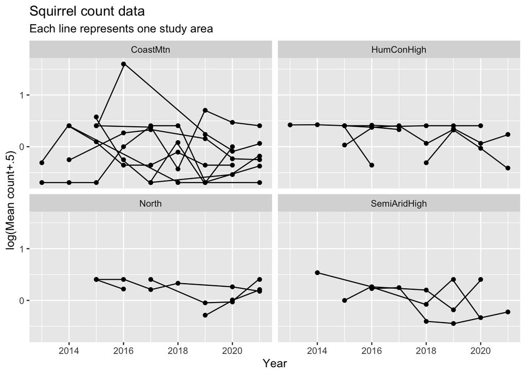

Figure 1: Summary plot of the data. The data is analyzed on the logarithmic scale.

### 3.1.3 Model

A non-parallel slope model is fit allowing for a different average slope (over the multiple STUDY_AREAs) in each EcoDomains (non-parallel slopes). Within each EcoDomain, each STUDY_AREA’s slope is allowed to vary randomly around the average slope for the EcoDomain. Within each STUDY_AREA, each transect is allowed to have a different intercept but common slope. Finally, we allow for year-specific factor within each EcoDomain.

The model, in a short-hand notation is:

$$log(AvgCalls+.5) \sim \mathit{EcoDomain} + \mathit{Year} + \mathit{EcoDomain}:\mathit{Year}+
\mathit{StudyArea} + \mathit{TransectF(R)} + \mathit{StudyArea}:\mathit{Year(R)} + \mathit{YearF:EcoDomain(R)}$$

where

- $log(AvgCalls)$ is logarithm of the average number of calls for that transect in that year. An offset of 0.5 is used to avoid taking the logarithm of 0.
- $\mathit{Year}$ term represents the average (over all EcoDomains) calendar year trend over time.
- $\mathit{EcoDomain}$ term represents a different intercept for each EcoDomain
- $\mathit{EcoDomain}:\mathit{Year}$ term represents the differential average slope for each EcoDomain
- $\mathit{StudyArea}:\mathit{Year(R)}$ term represents the random slopes within each EcoDomain for each study area
- $\mathit{TransectF(R)}$ represents the (random) transect effect;
- $\mathit{YearF:EcoDomain(R)}$ represents the (random) year-specific effects (process error), thare are allowed to vary across EcoDomains.

The The $\mathit{TransectF}$ term allows for the fact that transect-specific conditions may tend to affect the counts on this transect consistently over time. The $\mathit{YearF:EcoDomain}$ term represent the year-specific effects (process error) caused by environmental factors (e.g., a warmer than normal year may elict more calls from squirrels).

Model fit on the logarithmic scale assume that effects are multiplicative over time, so that the when the actual fit is done on the logarithmic scale, the trends are linear. For example, a trend may assume that there is constant 5% change over time rather than a fixed 1-unit change per year. Some caution is needed if any of the values are 0 as log(0) is not defined. In these cases, a small constant (typically ½ of the smallest positive value in the dataset) is added to all values before the analysis proceeds.

The model was fit using the *lmerTest()* function (Kuznetsova, 2017) in *R* (R Core Team, 2023).

```
boundary (singular) fit: see help('isSingular')
```

```
Type III Analysis of Variance Table with Satterthwaite's method
                 Sum Sq Mean Sq NumDF  DenDF F value    Pr(>F)
Year            2.76782 2.76782     1 408.33 18.8132 1.819e-05 ***
ECODOMAINF      0.29064 0.09688     3 410.16  0.6585    0.5780
Year:ECODOMAINF 0.29126 0.09709     3 410.16  0.6599    0.5771
---
Signif. codes:  0 '***' 0.001 '**' 0.01 '*' 0.05 '.' 0.1 ' ' 1
```

```
Linear mixed model fit by REML. t-tests use Satterthwaite's method ['lmerModLmerTest']
Formula: log(mean.calls + 0.5) ~ Year + ECODOMAINF + Year:ECODOMAINF +      (1 | STUDY_AREA_NAMEF) + (Year - 1 | STUDY_AREA_NAME) + (1 |      TRANSECTF) + (1 | YearF:ECODOMAINF)
   Data: count.transect

REML criterion at convergence: 459.1

Scaled residuals:
    Min      1Q  Median      3Q     Max
-2.5135 -0.7084  0.1182  0.5416  3.8785

Random effects:
 Groups           Name        Variance  Std.Dev.
 TRANSECTF        (Intercept) 7.106e-05 0.008430
 YearF:ECODOMAINF (Intercept) 7.395e-05 0.008599
 STUDY_AREA_NAME  Year        0.000e+00 0.000000
 STUDY_AREA_NAMEF (Intercept) 6.297e-02 0.250943
 Residual                     1.471e-01 0.383564
Number of obs: 421, groups:  TRANSECTF, 105; YearF:ECODOMAINF, 33; STUDY_AREA_NAME, 21; STUDY_AREA_NAMEF, 21

Fixed effects:
                              Estimate Std. Error         df t value Pr(>|t|)
(Intercept)                  83.644626  27.905911 404.623184   2.997  0.00289 **
Year                         -0.041522   0.013830 404.614136  -3.002  0.00285 **
ECODOMAINFHumConHigh        -11.344084  47.324740 410.914812  -0.240  0.81068
ECODOMAINFNorth             -16.009337  60.510050 387.337777  -0.265  0.79148
ECODOMAINFSemiAridHigh       64.880958  54.840288 400.843850   1.183  0.23747
Year:ECODOMAINFHumConHigh     0.005769   0.023459 410.908667   0.246  0.80588
Year:ECODOMAINFNorth          0.008097   0.029984 387.345589   0.270  0.78727
Year:ECODOMAINFSemiAridHigh  -0.032084   0.027179 400.835578  -1.180  0.23851
---
Signif. codes:  0 '***' 0.001 '**' 0.01 '*' 0.05 '.' 0.1 ' ' 1

Correlation of Fixed Effects:
              (Intr) Year   ECODOMAINFH ECODOMAINFN ECODOMAINFS Y:ECODOMAINFH Y:ECODOMAINFN
Year          -1.000
ECODOMAINFH   -0.590  0.590
ECODOMAINFN   -0.461  0.461  0.272
ECODOMAINFS   -0.509  0.509  0.300       0.235
Y:ECODOMAINFH  0.590 -0.590 -1.000      -0.272      -0.300
Y:ECODOMAINFN  0.461 -0.461 -0.272      -1.000      -0.235       0.272
Y:ECODOMAINFS  0.509 -0.509 -0.300      -0.235      -1.000       0.300         0.235
optimizer (nloptwrap) convergence code: 0 (OK)
boundary (singular) fit: see help('isSingular')
```

### 3.1.4 Test for no difference in trends among EcoDomains

After the model is fit, the ANOVA tables summarizes the test for no differences in trends among the EcoDomains in Table 1.

Table 1: ANOVA table for testing for differences in trends among EcoDomains

| Source | NumDF | DenDF | p.value |
| --- | --- | --- | --- |
| Year | 1 | 408.3 | p < .001 |
| ECODOMAIN | 3 | 410.2 | p = 0.578 |
| Year:ECODOMAIN | 3 | 410.2 | p = 0.577 |

The *Year:ECODOMAIN* term tests the hypothesis that the slopes in all of the EcoDomains are equal. If the p-value is large, then there is no evidence that the slopes among the EcoDomains are different.

### 3.1.5 Estimated slopes

The estimated coefficients from *R* output above do not have a direct interpretation because of the way that *R* codes the design matrix for discrete variables such as the EcoDomain.These coefficients associated with each EcoDomain are the difference in the slopes between the slope for that particular EcoDomain and the reference EcoDomain (typically the EcoDomain that is “first” alphabetically).

The estimated slope for each EcoDomain are estimated using the *emmeans* package (Lenth, 2023) presented in Table 2.

Table 2: Estimated slope in each EcoDomain

| Eco Domain | Slope | SE | df | 95% LCL | 95% UCL | Grouping |
| --- | --- | --- | --- | --- | --- | --- |
| SemiAridHigh | -0.0736 | 0.0234 | 399.3 | -0.1196 | -0.0276 | 1 |
| CoastMtn | -0.0415 | 0.0138 | 404.6 | -0.0687 | -0.0143 | 1 |
| HumConHigh | -0.0358 | 0.0189 | 406.8 | -0.0730 | 0.0015 | 1 |
| North | -0.0334 | 0.0266 | 366.1 | -0.0857 | 0.0189 | 1 |

Degrees-of-freedom method: satterthwaite  
Confidence level used: 0.95  
Note: contrasts are still on the 0.5(mu + 0.5) scale  
Degrees-of-freedom method: satterthwaite  
P value adjustment: tukey method for comparing a family of 4 estimates  
significance level used: alpha = 0.05  
NOTE: If two or more means share the same grouping symbol, then we cannot show them to be different. But we also did not show them to be the same.

The estimated trends (on the logarithmic scale) can be interpretted as the proportional change per year. For example, the slope of -0.042 in the CoastMtn EcoDomain can be interpretted as an approximate -4.2% change in the mean call rate per year.

The *Grouping* column indicates if there is evidence of a difference among the slopes across EcoDomains. EcoDomains that contain the same “digit” would indicate no evidence of a difference in the mean slopes among the EcoDomains. This is a summary of the overall p-value for parallelism found in the ANOVA table of p = 0.577. For more information on interpretting the *.group* variable, refer to https://schmidtpaul.github.io/DSFAIR/compactletterdisplay.html.

### 3.1.6 Mean slope over all EcoDomains

The average slope over all EcoDomains (giving each EcoDomain equal weight regardless of the number of study areas in the EcoDomain) shown in Table 3.

Table 3: Estimated mean slope over all EcoDomains

| Mean slope | Slope | SE | df | 95% LCL | 95% UCL | p.value |
| --- | --- | --- | --- | --- | --- | --- |
| overall | -0.0461 | 0.0106 | 408.3 | -0.0670 | -0.0252 | p < .001 |

Results are averaged over the levels of: ECODOMAINF  
Degrees-of-freedom method: satterthwaite  
Confidence level used: 0.95

The overall average slope over all EcoDomain is -0.046 (SE 0.011 with a p-value of p < .001. This is the same p-value from the ANOVA table for the *Year* term.

The estimated mean slope is interpreted in the same way as the slopes for each EcoDomain.

### 3.1.7 Summary plot

Figure 2 shows a summary plot, along with estimates of the slope, its standard error, and the p-value of the hypothesis of no trend in each EcoDomain.

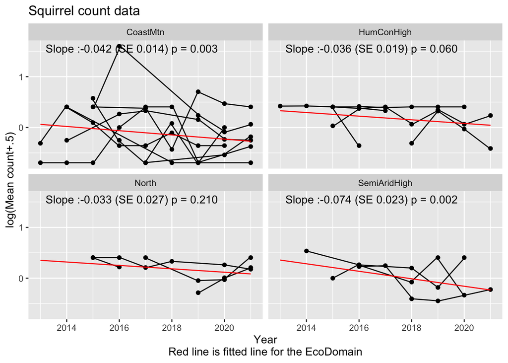

Figure 2: Summary plot of the trend in mean squirrel counts.

### 3.1.8 Estimated variance component

The estimated variance components are shown in Table 4.

Table 4: Estimated variance components

| Component | Interaction | SD |
| --- | --- | --- |
| TRANSECT |  | 0.008 |
| YearF:ECODOMAIN |  | 0.009 |
| STUDY_AREA_NAME | Year | 0.000 |
| STUDY_AREA_NAME |  | 0.251 |
| Residual |  | 0.384 |

The *STUDY_AREA_NAME* and *STUDY_AREA_NAME:Year* represent the variation in the intercepts and slopes among study areas within an EcoDomain. The *TRANSECT* component represents the variation in intercepts among multiple transects within the same STUDY_AREA. The *YearF:ECODOMAIN* components represents the variation in the year specific factors (process error) within the EcoDomains. Finally the *Residual* component represents the left-over, unexplained variation in the data.

Notice in this case, that the variation in the slopes for each STUDY_AREA within the EcoDomains is very close to 0, i.e., the different study areas could all have similar slopes within the EcoDomain. If you examine the individual slopes in each study area (see the individual study area reports), the estimated standard error is quite large indicating the the slopes could be roughly the same across study areas (see Figure 3).

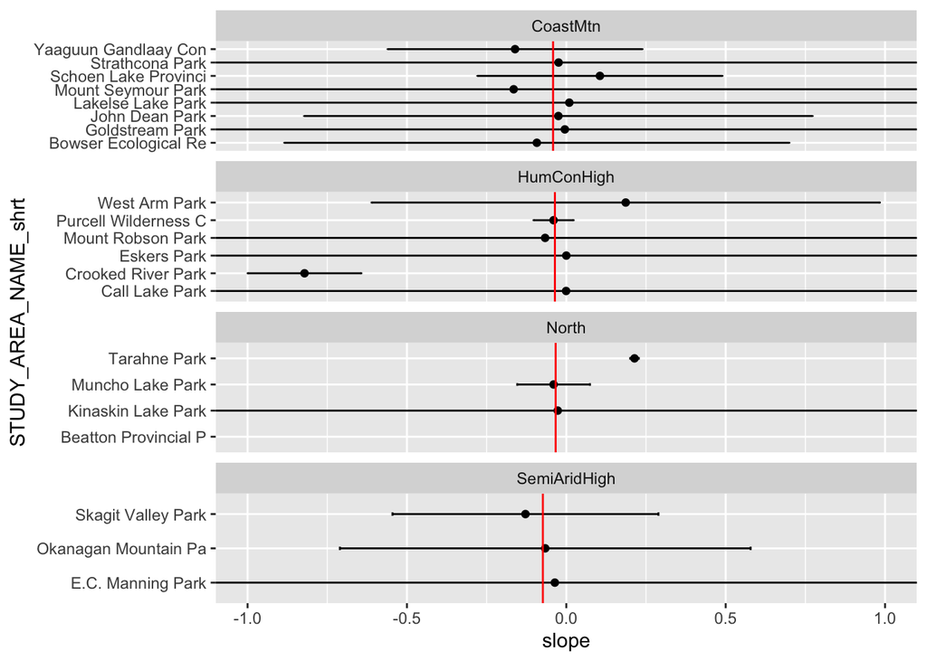

Figure 3: Comparing the individual slopes within each EcoRegion

The year specific effects vary slightly among the EcoDomains as shown in Figure 4.

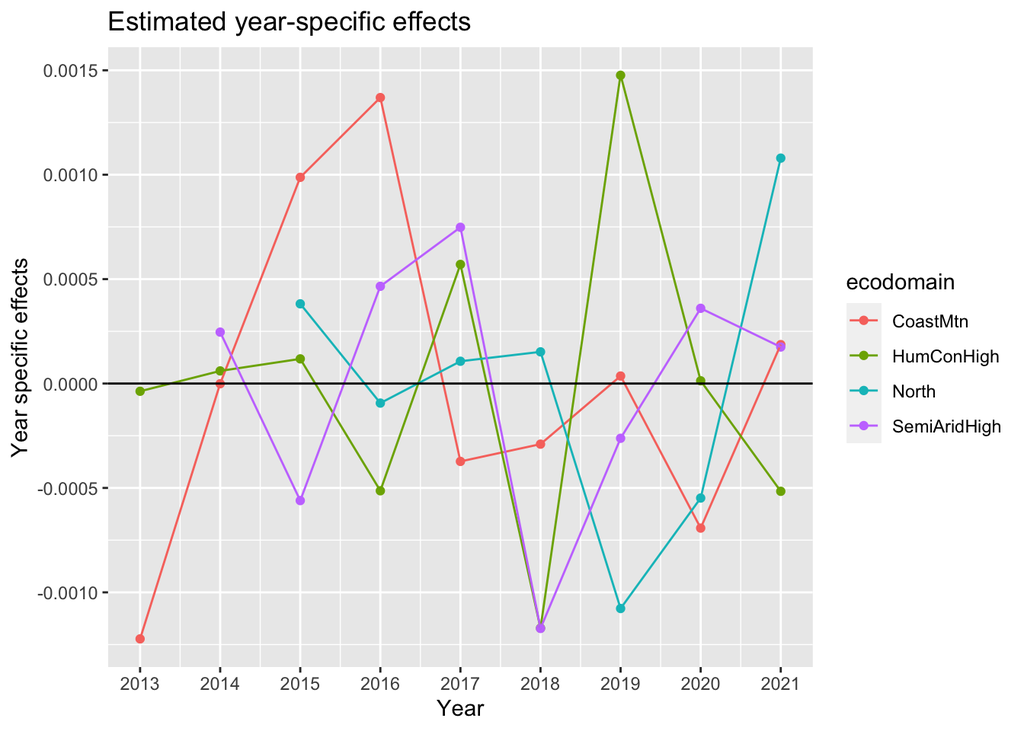

Figure 4: Plot of year specific effects

We see that the year-specific effects can vary across EcoDomains, e.g., the year-specific impact of weather can be different in the different EcoDomains. This is not surprising because B.C. is a large Province!

### 3.1.9 Residual plots

Residual plots are presented in Figure 5.

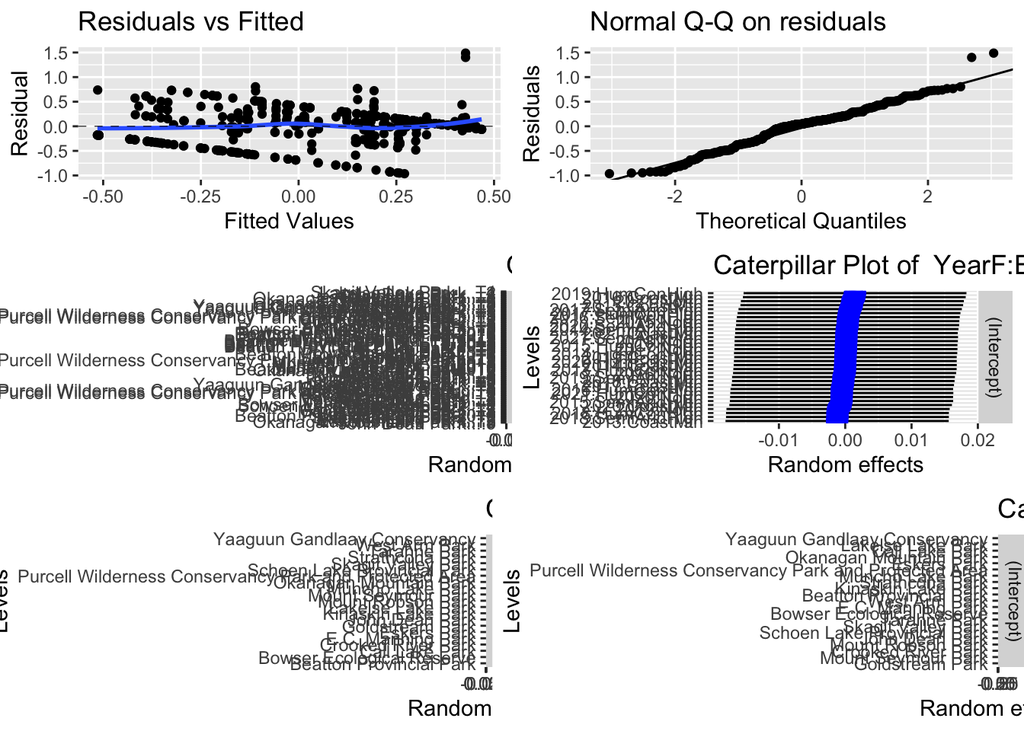

Figure 5: Model fit diagnostic plots from trend in mean transect counts

# 4 Power/sample size analysis

There are two hypotheses of most interest:

- What is the mean trend over all ecoregions. This is the *Year* effect test previously seen.
- Are there differences in the trend among ecoregions? This is the *Year:Ecoregion* test previously seen.

## 4.1 Power to detect mean trend.

We will first fit a simpler model that drops the *Year:Ecoregion* term in the model and fit a model with parallel slopes across the ecoregions (Figure 6).

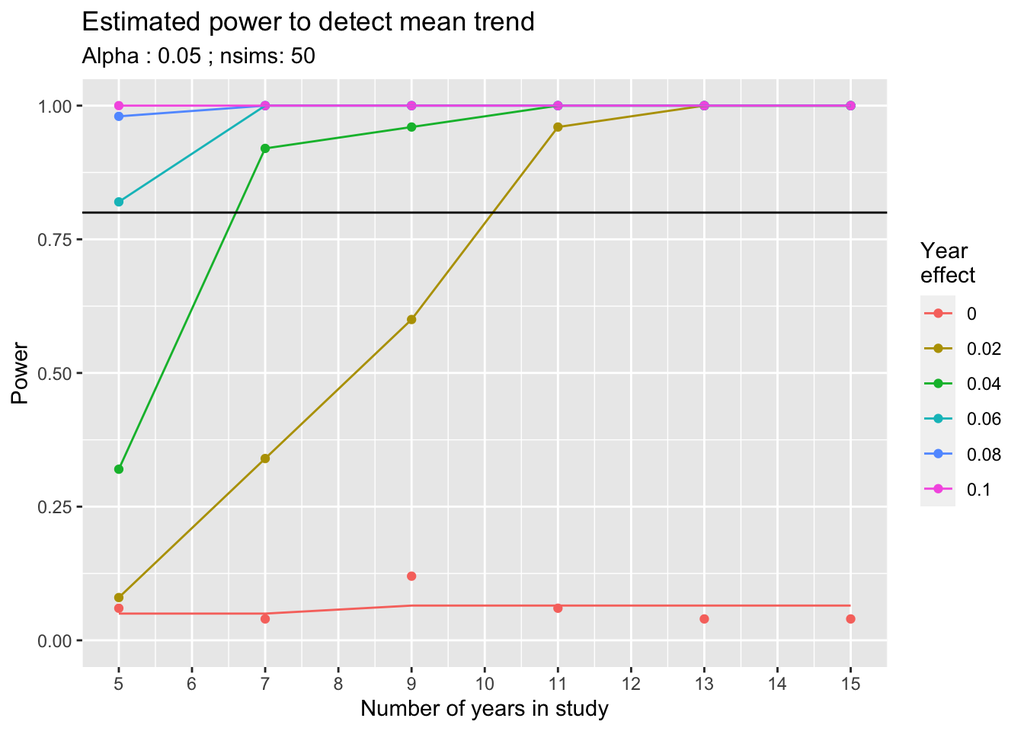

Figure 6: Estimated power to detect mean trend

The lines may appear to be “wiggly” or decline when moving from left to right, but this is an aretefact of a small number of simulations.

The *Year Effect* is the proportional change/year that is of interest. For example, a *Year Effect* of .02, implies a 2% change/year.

A target power of .80 (when alpha=0.05) is recommended (horizontal line on plots). This may not be achieved for small year effects with less than 10 year of sampling.

## 4.2 Power to detect differences in trends among EcoRegions.

We are now interested in the *Year:Ecoregion* term in the model and need to modify the size of this interaction. We will use the current model’s overall trend. Results are shown in Figure 7).

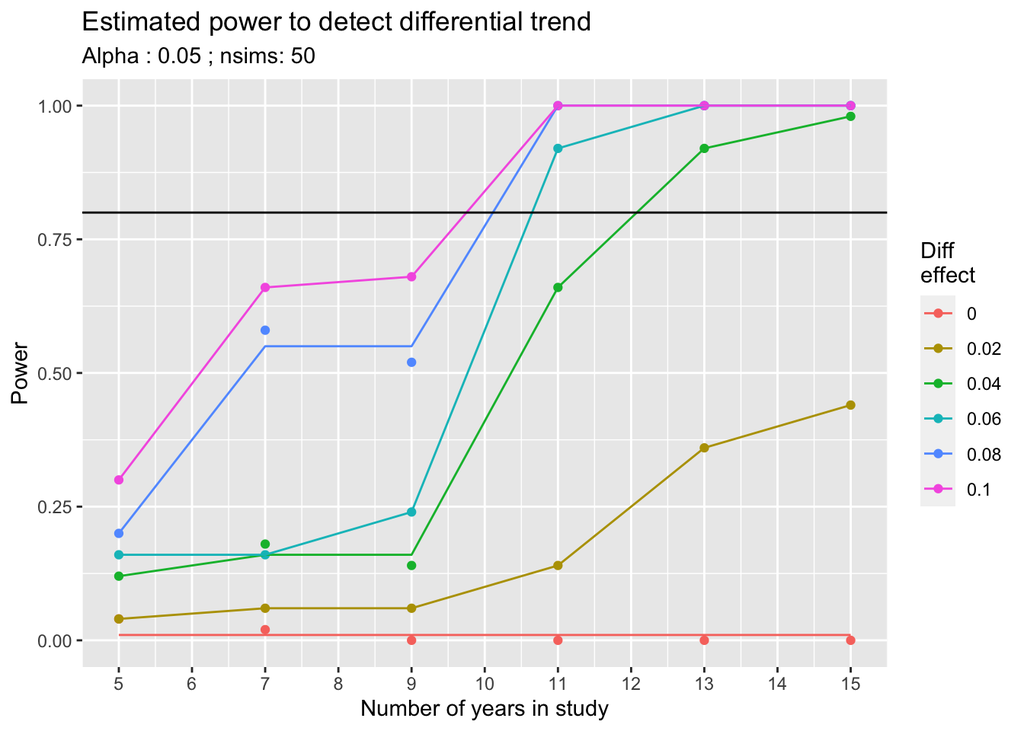

Figure 7: Estimated power to detect differential trend among EcoRegions

The lines may appear to be “wiggly” or decline when moving from left to right, but this is an aretefact of a small number of simulations.

The *Diff trend* is the DIFFERENCE in proportional change/year among the EcoRegions. For example, a *Diff trend* of 0 implies that all Ecoregions have the same trend. A *Diff trend* of .02, implies that the trends across the EcoRegions differs by 2 percentage points/year.

# 5 Summary

This analysis examines trends across EcoDomains. The model has an overall average trend, a EcoDomain specific trend, and random trends for each Study Area among the EcoDomain trends. With many study areas and many years of data collected in each study area, the design has a high power to detect even a moderate trend over time.

This model used the approximate analysis on the logarithm of the average counts per transect. It is possible to analyze the actual raw counts using a generalized linear mixed model – this was not done in this example because of the extreme smallness of the dataset. Once many more years are collected, this may be an alternative analysis that will more naturally deal with 0 counts without having to add a small constant.

# 6 References

Green P, MacLeod CJ (2016). simr: an R package for power analysis of generalised linear mixed models by simulation. Methods in Ecology and Evolution_, 7, 493-498. doi:10.1111/2041-210X.12504 https://doi.org/10.1111/2041-210X.12504,

Kuznetsova A, Brockhoff PB, Christensen RHB (2017). “lmerTest Package: Tests in Linear Mixed Effects Models.” Journal of Statistical Software, 82, 1-26. doi:10.18637/jss.v082.i13 https://doi.org/10.18637/jss.v082.i13.

Lenth R (2023). emmeans: Estimated Marginal Means, aka Least-Squares Means. R package version 1.8.4-1, https://CRAN.R-project.org/package=emmeans.